# Income and Education on Political Party

## Background

This analysis will be based off of the General Social Survey, which is a survey done for scientific research based on Americans and their development. I decided to test how the probability of being a democrat might change based off of income and education.

I will be using the following logistic regression equation to display my test:
$$P(Y_i = 1|\, x_{i1},x_{i22},\ldots,x_{i26}) = \frac{e^{\beta_0 + \beta_1 x_{i1} + \beta_2 x_{i22} + \ldots + \beta_6 x_{i26}}}{1+e^{{\beta_0 + \beta_1 x_{i1} + \beta_2 x_{i22} + \ldots + \beta_6 x_{i26}}}} = \pi_i$$

For this analysis, $Y_i=0$ denotes the political party being Republican of that individual and $Y_i=1$ would denote that the political party is Democrat. To explain each different variable, I’ve created the following table:

| Variable | Value | Explanation |
| --- | --- | --- |
| $x_{i1}$ | `0 to 180386` | the yearly income of the family |
| $x_{i22}$ | `neweduc == 1` | individual never finished High School |
| $x_{i23}$ | `neweduc == 2` | individual has graduated High School |
| $x_{i24}$ | `neweduc == 3` | individual has less than 4 years of college after High School |
| $x_{i25}$ | `neweduc == 4` | individual has 4 years of college after High School |
| $x_{i26}$ | `neweduc == 5` | individual has 5-8 years of college after High School |

My hypothesis to be tested by the logistic regression will be the following:
$$H_0: \beta_0 = 0 \\
H_a: \beta_0 \neq 0$$
$$H_0: \beta_2 = 0 \\
H_a: \beta_2 \neq 0$$
$$H_0: \beta_3 = 0 \\
H_a: \beta_3 \neq 0$$
$$H_0: \beta_4 = 0 \\
H_a: \beta_4 \neq 0$$
$$H_0: \beta_5 = 0 \\
H_a: \beta_5 \neq 0$$

$$H_0: \beta_6 = 0 \\
H_a: \beta_6 \neq 0$$

## Data

```r
datatable(GSS4,options = list(lengthMenu=c(5,10,30,100)))
```

|  | coninc | neweduc | newparty | age |
| --- | --- | --- | --- | --- |
| 1 | 178712.4649 | 4 | Democrat | 22 |
| 2 | 178712.4649 | 2 | Republican | 21 |
| 3 | 91920 | 2 | Democrat | 42 |
| 4 | 107240 | 3 | Republican | 49 |
| 5 | 42130 | 4 | Democrat | 70 |
| 6 | 21065 | 5 | Democrat | 50 |
| 10 | 24895 | 5 | Democrat | 28 |
| 11 | 383 | 1 | Democrat | 55 |
| 12 | 42130 | 4 | Democrat | 36 |
| 16 | 42130 | 3 | Republican | 35 |

[output cut: 1522 more lines]

## Analysis

I created the following plot to portray the variables and how they appear in relation to each other.

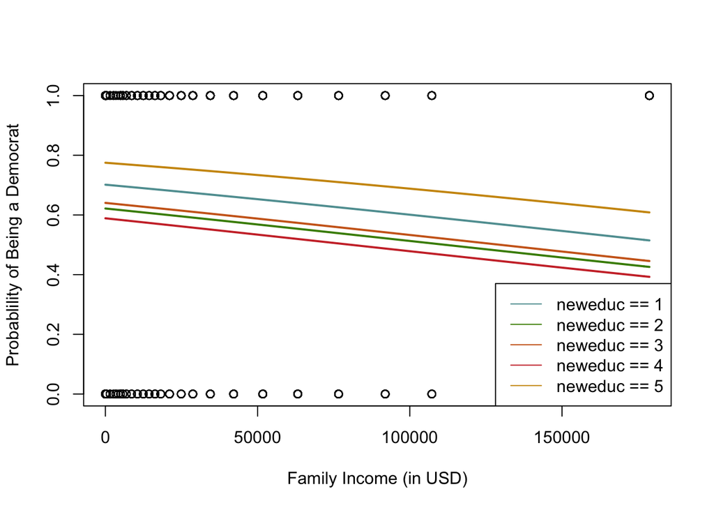

```r
plot(newparty=='Democrat'~coninc, data=GSS4, xlab='Family Income (in USD)', ylab='Probablility of Being a Democrat')
curve(exp(b[1]+b[2]*x)/(1+exp(b[1]+b[2]*x)), add=TRUE, col='cadetblue', lwd=2)
curve(exp(b[1]+b[3]+b[2]*x)/(1+exp(b[1]+b[3]+b[2]*x)), add=TRUE, col='chartreuse4', lwd=2)
curve(exp(b[1]+b[4]+b[2]*x)/(1+exp(b[1]+b[4]+b[2]*x)), add=TRUE, col='chocolate3', lwd=2)
curve(exp(b[1]+b[5]+b[2]*x)/(1+exp(b[1]+b[5]+b[2]*x)), add=TRUE, col='brown3', lwd=2)
curve(exp(b[1]+b[6]+b[2]*x)/(1+exp(b[1]+b[6]+b[2]*x)), add=TRUE, col='darkgoldenrod3', lwd=2)
legend("bottomright",legend=paste("neweduc ==", 1:5), col=c("cadetblue","chartreuse4","chocolate3","brown3","darkgoldenrod3"), lty=1)
```

This plot is based off the following table which presents the statistics from a Logistic Regression test.

```r
GSS2012<-GSS
GSS2012$neweduc<-mapvalues(GSS2012$educ, c(0,1,2,3,4,5,6,7,8,9,10,11,12,13,14,15,16,17,18,19,20), c(rep('1', 12), '2', rep('3', 3), '4', rep("5", 4)))
GSSC<-GSS2012[c('coninc', 'neweduc', 'partyid', 'age')]
GSSC$newparty<-mapvalues(GSSC$partyid, c(0,1,2,4,5,6), c(rep('Democrat', 3), c(rep('Republican', 3))))
GSS2<-GSSC[c('coninc', 'neweduc', 'newparty', 'age')]
GSS3<-subset(GSS2, newparty=='Democrat'|newparty=='Republican')
GSS4<-subset(GSS3, neweduc!=98)
litglm<-glm(newparty=='Democrat'~coninc+neweduc, data=GSS4, family=binomial)
b<-coefficients(litglm)
pander(summary(litglm))
```

|  | Estimate | Std. Error | z value | Pr(>\|z\|) |
| --- | --- | --- | --- | --- |
| **(Intercept)** | 0.854 | 0.1544 | 5.532 | 3.17e-08 |
| **coninc** | -4.45e-06 | 1.234e-06 | -3.607 | 0.0003093 |
| **neweduc2** | -0.3574 | 0.1837 | -1.946 | 0.0517 |
| **neweduc3** | -0.2769 | 0.1837 | -1.508 | 0.1317 |
| **neweduc4** | -0.495 | 0.2062 | -2.401 | 0.01636 |
| **neweduc5** | 0.3824 | 0.2233 | 1.712 | 0.08684 |

(Dispersion parameter for binomial family taken to be 1 )

| Null deviance: | 2050 on 1531 degrees of freedom |
| --- | --- |
| Residual deviance: | 2012 on 1526 degrees of freedom |

In order to find if this logistic regression was relevant and appropriate, I performed a goodness of fit test. The null hypothesis is that logistic regression is appropriate. The p-value for the goodness of fit test is the following:

```r
pander(pchisq(2011.6, 1526, lower.tail = FALSE))
```

*5.665e-16*

Thus, we see that there is sufficient evidence to reject the null hypothesis. A logistic regression is not apprpriate for this data. However, I will continue to do the interpretation to interpret what the data says if it was apprpriate.